# Factor Analysis

ChatGPT 4o

2024-11-20

## 1 起源

因子分析（Factor Analysis）是一种用于数据降维和探索潜在结构的统计方法，最早由心理学家查尔斯·斯皮尔曼（Charles Spearman）在20世纪初提出，用于分析心理学测试中不同能力之间的相关性。之后，因子分析被逐渐推广到其他领域，如社会科学、市场营销和金融，帮助研究人员从大量变量中提取出少数潜在因子，解释数据的共性特征。

## 2 原理

因子分析的基本原理是通过识别和提取数据中潜在的公共因子来解释变量之间的相关性。因子分析假设每个观测变量可以由少数潜在因子和特定因素组成，数学模型为：

$$X_i = \lambda_{i1} F_1 + \lambda_{i2} F_2 + \cdots + \lambda_{im} F_m +
\epsilon_i$$

其中，$X_i$ 表示第 $i$ 个观测变量，$F_1, F_2, \cdots, F_m$ 为潜在因子，$\lambda_{ij}$ 为因子载荷（表示因子对变量的影响程度），$\epsilon_i$ 为特定因素（无法由因子解释的部分）。

通过因子载荷矩阵，可以了解每个变量在各个因子上的权重。常用的因子分析方法包括主成分法（Principal Component Method）和最大似然法（Maximum Likelihood Method）。此外，因子旋转（如Varimax旋转）可以使得因子具有更好的解释性。

## 3 适用范围

因子分析适用于以下情况：

- **探索潜在结构**：数据集中存在多个变量，且这些变量之间存在较强的相关性，希望探索其背后的潜在因子。
- **数据降维**：用于减少变量数量，同时尽可能多地保留原始信息。
- **构建量表**：在心理学和社会学中，因子分析常用于量表构建，通过提取主要因子来解释不同题项之间的关联。

## 4 应用情境

因子分析在许多领域中得到了广泛应用，例如：

- **心理学**：用于探索不同心理测试题之间的共性特征，揭示潜在的心理因素。
- **市场研究**：用于识别消费者行为背后的潜在驱动因素，如价格敏感性和品牌忠诚度。
- **教育研究**：用于分析学生不同学科成绩之间的关系，找出潜在的学习能力因子。
- **金融分析**：用于简化金融指标，识别影响市场走势的主要因素。

## 5 优缺点

### 优点

- **揭示潜在结构**：因子分析能够从复杂的数据集中提取潜在因子，揭示变量之间的潜在结构。
- **数据降维**：有效减少变量数量，降低模型的复杂度，便于后续分析。
- **量表构建**：在心理学等领域，可以用于开发结构良好的量表。

### 缺点

- **对数据要求较高**：因子分析要求变量之间具有较高的相关性，且数据应符合正态分布。
- **因子解释困难**：提取的因子是抽象的线性组合，物理意义通常不易解释。
- **对异常值敏感**：因子分析对异常值敏感，异常值可能会影响因子的提取和解释。

## 6 在R中的实现及结果解释

在R中，可以使用`psych`包中的`fa()`函数实现因子分析。以下是一个实现示例：

```r
# 加载必要的包
library(psych)

# 示例数据：内置的mtcars数据集
data <- mtcars

# 进行因子分析，假设提取2个因子
fa_result <- fa(data, nfactors = 2, rotate = "varimax")

# 输出因子分析结果
print(fa_result)
```

```
## Factor Analysis using method =  minres
## Call: fa(r = data, nfactors = 2, rotate = "varimax")
## Standardized loadings (pattern matrix) based upon correlation matrix
##        MR1   MR2   h2    u2 com
## mpg   0.68 -0.63 0.85 0.147 2.0
## cyl  -0.63  0.73 0.94 0.064 2.0
## disp -0.73  0.61 0.90 0.102 1.9
## hp   -0.32  0.88 0.88 0.124 1.3
## drat  0.81 -0.22 0.71 0.292 1.1
## wt   -0.78  0.45 0.82 0.179 1.6
## qsec -0.15 -0.87 0.78 0.216 1.1
## vs    0.30 -0.79 0.71 0.292 1.3
## am    0.90  0.07 0.82 0.183 1.0
## gear  0.88  0.15 0.80 0.200 1.1
## carb  0.05  0.81 0.66 0.342 1.0
##
##                        MR1  MR2
## SS loadings           4.46 4.39
## Proportion Var        0.41 0.40
## Cumulative Var        0.41 0.81
## Proportion Explained  0.50 0.50
## Cumulative Proportion 0.50 1.00
##
## Mean item complexity =  1.4
## Test of the hypothesis that 2 factors are sufficient.
##
## df null model =  55  with the objective function =  15.4 with Chi Square =  408.01
## df of  the model are 34  and the objective function was  2.76
##
## The root mean square of the residuals (RMSR) is  0.04
## The df corrected root mean square of the residuals is  0.06
##
## The harmonic n.obs is  32 with the empirical chi square  6.87  with prob <  1
## The total n.obs was  32  with Likelihood Chi Square =  69.56  with prob <  0.00031
##
## Tucker Lewis Index of factoring reliability =  0.827
## RMSEA index =  0.178  and the 90 % confidence intervals are  0.121 0.245
## BIC =  -48.28
## Fit based upon off diagonal values = 0.99
## Measures of factor score adequacy
##                                                    MR1  MR2
## Correlation of (regression) scores with factors   0.98 0.98
## Multiple R square of scores with factors          0.95 0.96
## Minimum correlation of possible factor scores     0.91 0.92
```

### 结果解释

- **因子载荷矩阵（Factor Loadings）**：因子载荷矩阵显示了每个变量在各个因子上的载荷值，表示每个变量与因子的相关性大小。较大的载荷值表示该变量在该因子上的贡献较大。
- **共同度（Communality）**：每个变量的共同度表示该变量中可以由提取的因子解释的部分，值越高表示因子对该变量的解释力越强。
- **独特性（Uniqueness）**：独特性是1减去共同度，表示变量中无法由因子解释的部分。

在进行因子分析之前，需要确保数据符合一些假设条件，以确保结果的可靠性：

- **变量之间的相关性**：因子分析要求变量之间具有较高的相关性。可以通过计算相关矩阵，并查看Kaiser-Meyer-Olkin（KMO）测度和Bartlett球形度检验来检查相关性。
  - **KMO测度**：用于评估因子分析的适用性，KMO值越接近1，表示变量之间的相关性越适合进行因子分析，通常KMO值大于0.6被认为适合。
  - **Bartlett球形度检验**：用于检验变量之间是否具有足够的相关性进行因子分析，显著的p值（小于0.05）表明适合进行因子分析。

```r
# 计算KMO测度和Bartlett球形度检验
kmo_result <- KMO(data)
bartlett_result <- cortest.bartlett(data)
```

```
## R was not square, finding R from data
```

```r
# 输出结果
print(kmo_result)
```

```
## Kaiser-Meyer-Olkin factor adequacy
## Call: KMO(r = data)
## Overall MSA =  0.83
## MSA for each item =
##  mpg  cyl disp   hp drat   wt qsec   vs   am gear carb
## 0.93 0.90 0.76 0.84 0.95 0.74 0.74 0.91 0.88 0.85 0.62
```

```r
print(bartlett_result)
```

```
## $chisq
## [1] 408.0116
##
## $p.value
## [1] 2.226927e-55
##
## $df
## [1] 55
```

### 因子提取方法

因子提取是因子分析中的关键步骤，常用的因子提取方法包括：

- **主成分法（Principal Component Method）**：通过提取主成分来作为因子，保留数据中尽可能多的方差。
- **最大似然法（Maximum Likelihood Method）**：通过最大化似然函数来提取因子，适用于数据符合正态分布的情况。

在R中，可以通过`fa()`函数的`fm`参数来指定因子提取方法，例如：

```r
# 使用最大似然法进行因子分析
fa_result_ml <- fa(data, nfactors = 2, fm = "ml")
print(fa_result_ml)
```

```
## Factor Analysis using method =  ml
## Call: fa(r = data, nfactors = 2, fm = "ml")
## Standardized loadings (pattern matrix) based upon correlation matrix
##        ML1   ML2   h2    u2 com
## mpg  -0.53  0.60 0.83 0.167 2.0
## cyl   0.67 -0.52 0.93 0.070 1.9
## disp  0.53 -0.65 0.90 0.096 1.9
## hp    0.85 -0.20 0.86 0.143 1.1
## drat -0.13  0.79 0.70 0.298 1.1
## wt    0.33 -0.76 0.83 0.168 1.4
## qsec -0.96 -0.32 0.85 0.150 1.2
## vs   -0.80  0.16 0.74 0.256 1.1
## am    0.20  0.95 0.83 0.171 1.1
## gear  0.24  0.91 0.75 0.246 1.1
## carb  0.81  0.16 0.61 0.386 1.1
##
##                        ML1  ML2
## SS loadings           4.43 4.42
## Proportion Var        0.40 0.40
## Cumulative Var        0.40 0.80
## Proportion Explained  0.50 0.50
## Cumulative Proportion 0.50 1.00
##
##  With factor correlations of
##       ML1   ML2
## ML1  1.00 -0.29
## ML2 -0.29  1.00
##
## Mean item complexity =  1.4
## Test of the hypothesis that 2 factors are sufficient.
##
## df null model =  55  with the objective function =  15.4 with Chi Square =  408.01
## df of  the model are 34  and the objective function was  2.72
##
## The root mean square of the residuals (RMSR) is  0.05
## The df corrected root mean square of the residuals is  0.06
##
## The harmonic n.obs is  32 with the empirical chi square  7.66  with prob <  1
## The total n.obs was  32  with Likelihood Chi Square =  68.57  with prob <  4e-04
##
## Tucker Lewis Index of factoring reliability =  0.832
## RMSEA index =  0.175  and the 90 % confidence intervals are  0.118 0.243
## BIC =  -49.27
## Fit based upon off diagonal values = 0.99
## Measures of factor score adequacy
##                                                    ML1  ML2
## Correlation of (regression) scores with factors   0.98 0.98
## Multiple R square of scores with factors          0.96 0.96
## Minimum correlation of possible factor scores     0.92 0.92
```

### 因子旋转方法

因子旋转用于使因子具有更清晰的解释性，常见的因子旋转方法包括：

- **正交旋转（Orthogonal Rotation）**：如Varimax旋转，保持因子之间的正交性，使得每个因子的载荷更加清晰，易于解释。
- **斜交旋转（Oblique Rotation）**：如Promax旋转，允许因子之间存在相关性，使得模型更加符合实际数据结构。

在R中，可以使用`fa()`函数的`rotate`参数来指定旋转方法，例如：

```r
# 使用Promax旋转进行因子分析
fa_result_promax <- fa(data, nfactors = 2, rotate = "promax")
print(fa_result_promax)
```

```
## Factor Analysis using method =  minres
## Call: fa(r = data, nfactors = 2, rotate = "promax")
## Standardized loadings (pattern matrix) based upon correlation matrix
##        MR1   MR2   h2    u2 com
## mpg   0.58 -0.52 0.85 0.147 2.0
## cyl  -0.51  0.63 0.94 0.064 1.9
## disp -0.64  0.48 0.90 0.102 1.9
## hp   -0.13  0.87 0.88 0.124 1.0
## drat  0.82 -0.04 0.71 0.292 1.0
## wt   -0.74  0.30 0.82 0.179 1.3
## qsec -0.37 -0.98 0.78 0.216 1.3
## vs    0.13 -0.78 0.71 0.292 1.1
## am    0.99  0.29 0.82 0.183 1.2
## gear  0.99  0.38 0.80 0.200 1.3
## carb  0.26  0.89 0.66 0.342 1.2
##
##                        MR1  MR2
## SS loadings           4.47 4.39
## Proportion Var        0.41 0.40
## Cumulative Var        0.41 0.81
## Proportion Explained  0.50 0.50
## Cumulative Proportion 0.50 1.00
##
##  With factor correlations of
##       MR1   MR2
## MR1  1.00 -0.43
## MR2 -0.43  1.00
##
## Mean item complexity =  1.4
## Test of the hypothesis that 2 factors are sufficient.
##
## df null model =  55  with the objective function =  15.4 with Chi Square =  408.01
## df of  the model are 34  and the objective function was  2.76
##
## The root mean square of the residuals (RMSR) is  0.04
## The df corrected root mean square of the residuals is  0.06
##
## The harmonic n.obs is  32 with the empirical chi square  6.87  with prob <  1
## The total n.obs was  32  with Likelihood Chi Square =  69.56  with prob <  0.00031
##
## Tucker Lewis Index of factoring reliability =  0.827
## RMSEA index =  0.178  and the 90 % confidence intervals are  0.121 0.245
## BIC =  -48.28
## Fit based upon off diagonal values = 0.99
## Measures of factor score adequacy
##                                                    MR1  MR2
## Correlation of (regression) scores with factors   0.98 0.98
## Multiple R square of scores with factors          0.97 0.97
## Minimum correlation of possible factor scores     0.93 0.94
```

通过使用不同的旋转方法，可以使得因子载荷矩阵更加稀疏，从而更容易理解每个因子的物理意义。

### 结果的可视化

可以使用`psych`包中的`fa.diagram()`函数对因子分析的结果进行可视化，以展示因子与变量之间的关系。

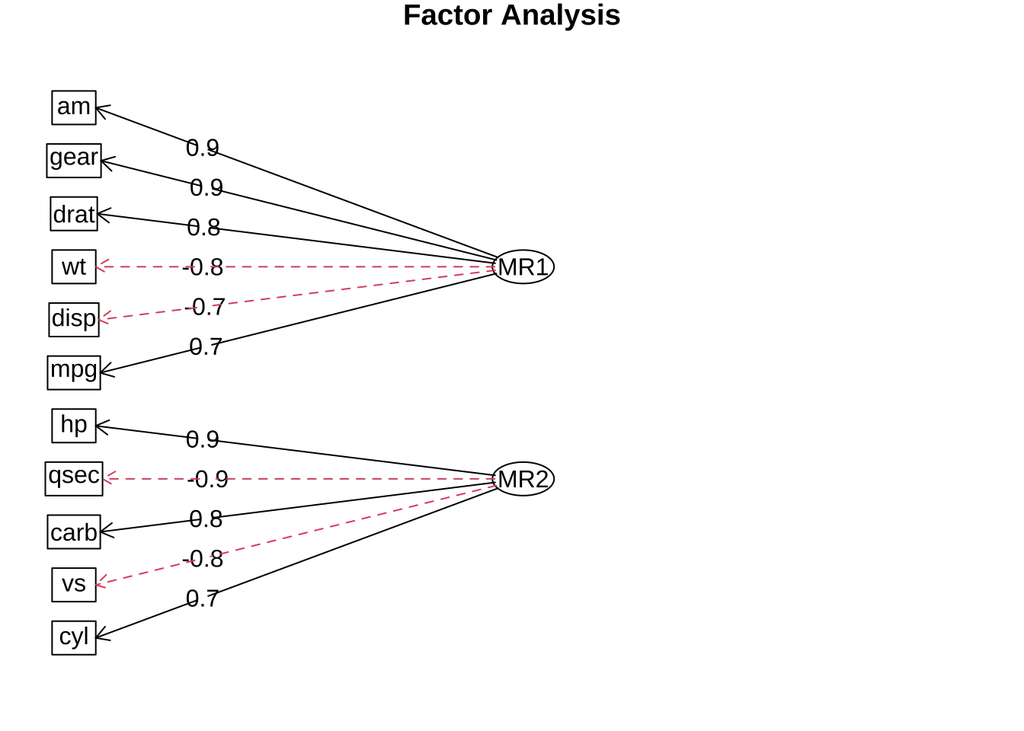

```r
# 绘制因子分析的路径图
fa.diagram(fa_result)
```

上述代码将生成因子分析的路径图，展示每个因子与各变量之间的关系，使得因子的解释性更加直观。

## 7 小结

- 因子分析是一种用于数据降维和探索潜在结构的统计方法，能够从大量变量中提取少数几个潜在因子。
- 适用于探索数据背后的潜在结构、减少变量数量，并在心理学、市场研究和金融分析中应用广泛。
- 具有揭示潜在结构、数据降维的优点，但对数据要求较高，因子物理解释困难。
- 可以通过R中的`fa()`函数实现因子分析，并结合可视化更直观地展示因子与变量的关系。
- 在各个领域中，因子分析是揭示数据潜在结构的重要工具，尤其适用于探索性数据分析。